# Taller individual 1 - Análisis Exploratorio de Datos, Universidad ICESI

Jorge Antonio Morales

22/2/2022

### 1. Objetivo del proyecto

El objetivo del proyecto de analítica es determinar si existe una relación entre el puntaje de las pruebas saber 11 y la deserción de los estudiantes en los primeros tres semestres en la Universidad ICESI.

### 2. Tipos de variables

- **Código:** Cualitativa nominal
- **Facultad:** Cualitativa nominal
- **Cohorte:** Cualitativa ordinal
- **Tipo_prog:** Cualitativa nominal
- **Género:** Cualitativa nominal
- **Estrato:** Cualitativa ordinal
- **Ciudad_proc:** Cualitativa nominal
- **Edad_entrada:** Cualitativa nominal
- **PG:** Cuantitativa discreta
- **PLC:** Cuantitativa discreta
- **PMA:** Cuantitativa discreta
- **PSC:** Cuantitativa discreta
- **PCN:** Cuantitativa discreta
- **PIN:** Cuantitativa discreta
- **Intercambio_entrante:** Cualitativa nominal
- **Deserta:** Cualitativa nominal
- **Educ_madre:** Cualitativa nominal
- **Educ_padre:** Cualitativa nominal

### 3. Filtrar por programa principal

```r
base = base[base$Tipo_prog == "Principal",]
```

### 4. Caso extranjeros

Para este proyecto se decidió eliminar a los extranjeros (Listwise Deletion) debido a que estos no presentaros la prueba saber 11 y ésta es la principal variable para decidir si existe una relación entre el puntaje y la deserción. Además de que estos corresponden al 3% de los datos.

**Nota:** La variable fue eliminada debido a que fue tomada como un Missing Complete At Random puesto que no existe cómo controlar cuando un estudiante es de intercambio o no.

```r
tabla_freq(base$Intercambio_entrante)
```

```
##   Categoría Freq. Abs. Freq. Rel.
## 1         N       5579 0.96189655
## 2         S        221 0.03810345
## 3     Total       5800 1.00000000
```

```r
base = base[base$Intercambio_entrante == "N", ]
```

### 5. Anomalías Edad

Debido a que la edad es una variable cualitativa nominal debido al “16 o menos” y “19 o más”, esta no tiene datos atípicos, inválidos e inconsistentes. Además de que no cuenta con campos vacíos.

```r
tabla_freq(base$Edad_entrada)
```

```
##    Categoría Freq. Abs. Freq. Rel.
## 1 16 o menos       1144  0.2050547
## 2         17       2502  0.4484675
## 3         18       1321  0.2367808
## 4   19 o más        612  0.1096971
## 5      Total       5579  1.0000000
```

### 6. Anomalías Ciudad

Existen errores de digitación para los atributos Popayán y Tuluá puesto que algunos no cuentan con la tílde. Por otro lado, no existen campos vacíos, valores atípicos ni inconsistencias debido a que no se encuentra el atributo “Extranjero” debido a que fueron eliminados los estudiantes de intercambio.

```r
tabla_freq(base$Ciudad_proc)
```

```
##              Categoría Freq. Abs.  Freq. Rel.
## 1                 Buga        116 0.020792257
## 2                 Cali       3206 0.574654956
## 3  Guadalajara de Buga         28 0.005018821
## 4       Otras ciudades       1080 0.193583079
## 5              Palmira        463 0.082989783
## 6                Pasto        223 0.039971321
## 7              Popayan         34 0.006094282
## 8              Popayán        162 0.029037462
## 9                Tulua         23 0.004122603
## 10               Tuluá        105 0.018820577
## 11               Yumbo        139 0.024914859
## 12               Total       5579 1.000000000
```

```r
base$Ciudad_proc[base$Ciudad_proc == "Popayan"] = "Popayán"
base$Ciudad_proc[base$Ciudad_proc == "Tulua"] = "Tuluá"
```

### 7. Anomalía Educ_padre y Educ_madre

Existen anomalías por campos vacíos para las dos variables, las cuales corresponden al 56% de los datos para ambos casos. Puesto que la cantidad de campos vacíos es demasiado elevada, dichas variables ya no son representativas y se proceden a eliminar.

```r
tabla_freq(base$Educ_madre)
```

```
##     Categoría Freq. Abs. Freq. Rel.
## 1     Ninguna        184 0.03298082
## 2    Posgrado        270 0.04839577
## 3    Primaria        270 0.04839577
## 4 Profesional       1105 0.19806417
## 5  Secundaria        426 0.07635777
## 6         TyT        144 0.02581108
## 7        <NA>       3180 0.56999462
## 8       Total       5579 1.00000000
```

```r
tabla_freq(base$Educ_padre)
```

```
##     Categoría Freq. Abs. Freq. Rel.
## 1     Ninguna        169 0.03029217
## 2    Posgrado        274 0.04911274
## 3    Primaria        279 0.05000896
## 4 Profesional        707 0.12672522
## 5  Secundaria        811 0.14536655
## 6         TyT        182 0.03262233
## 7        <NA>       3157 0.56587202
## 8       Total       5579 1.00000000
```

```r
base$Educ_madre <- NULL
base$Educ_padre <- NULL
```

### 8. Anomalías Puntaje Global

Existen campos vacíos y datos inválidos. Sin embargo, es muy probable que los valores de esta variable se hubiesen visto afectado por los puntajes para cada materia.

```r
# Verificar anomalías
summary(base$PG)
```

```
##    Min. 1st Qu.  Median    Mean 3rd Qu.    Max.    NA's
##   222.0   320.0   346.0   365.2   372.0   921.0     548
```

**Se procede a revisar cada una de las variables de los puntajes específicos**

#### PMA

No contiene ninguna anomalía.

```r
summary(base$PMA)
```

```
##    Min. 1st Qu.  Median    Mean 3rd Qu.    Max.
##   29.00   62.00   69.00   68.72   76.00  100.00
```

#### PLC

No contiene ninguna anomalía

```r
summary(base$PLC)
```

```
##    Min. 1st Qu.  Median    Mean 3rd Qu.    Max.
##   39.00   62.00   68.00   67.79   73.00  100.00
```

#### PSC

No contiene ninguna anomalía

```r
summary(base$PSC)
```

```
##    Min. 1st Qu.  Median    Mean 3rd Qu.    Max.
##   38.00   62.00   68.00   67.92   74.00  100.00
```

#### PCN

No contiene ninguna anomalía

```r
summary(base$PCN)
```

```
##    Min. 1st Qu.  Median    Mean 3rd Qu.    Max.
##   35.00   63.00   69.00   69.12   75.00  100.00
```

#### PIN

No contiene ninguna anomalía

```r
summary(base$PIN)
```

```
##    Min. 1st Qu.  Median    Mean 3rd Qu.    Max.
##   25.00   63.00   72.00   71.72   81.00  100.00
```

Se descarta la presencia de alguna anomalía para las variables de los puntajes. Ahora se procede a mirar más a detalle los inconvenientes con el puntaje global.

```r
tabla_freq(base$PG[base$PG > 500])
```

```
##   Categoría Freq. Abs. Freq. Rel.
## 1       699         50 0.06345178
## 2       784         46 0.05837563
## 3       787         50 0.06345178
## 4       833         47 0.05964467
## 5       921         47 0.05964467
## 6      <NA>        548 0.69543147
## 7     Total        788 1.00000000
```

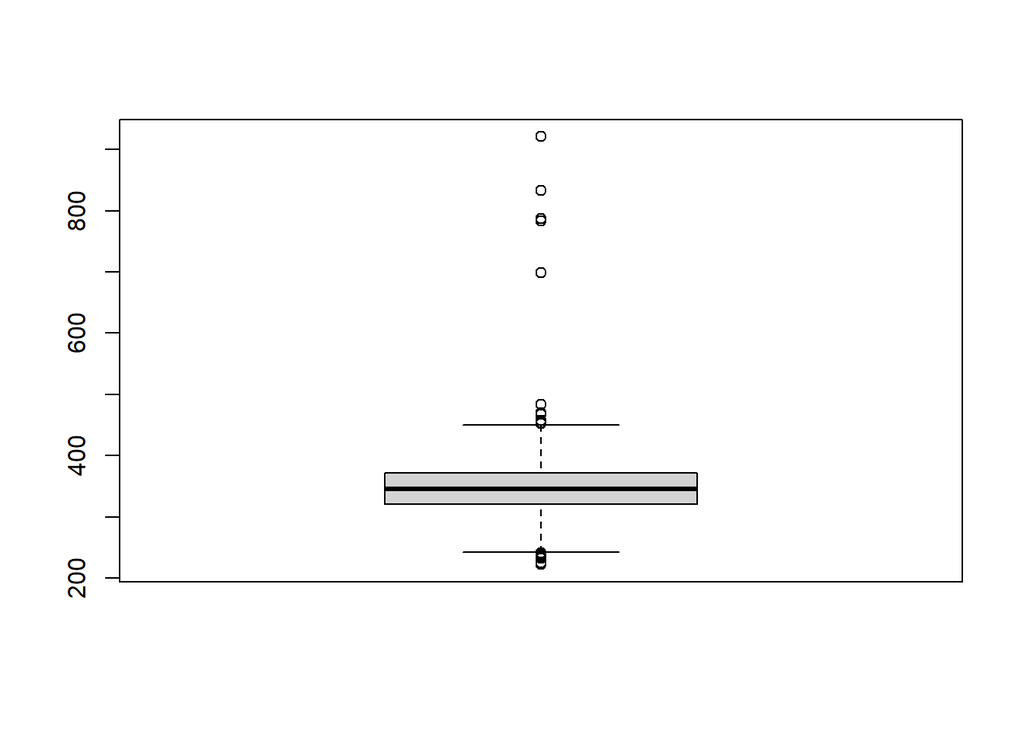

```r
boxplot(base$PG)
```

Se puede determinar que existen 240 datos (4.3% de la población) que son inválidos. Para este caso se calculará nuevamente el puntaje global teniendo en cuenta la información del ICFES.

```r
#FUNCIÓN PARA CALCULAR EL PUNTAJE GLOBAL
calcular_puntaje = function(PMA, PLC, PSC, PCN, PIN) {
  as.integer(((PMA*3 + PLC*3 + PSC*3 + PCN*3 + PIN)/13)*5)
}

#REASIGNAR EL PUNTAJE GLOBAL
base$PG = calcular_puntaje(base$PMA, base$PLC, base$PSC, base$PCN, base$PIN)

summary(base$PG)
```

```
##    Min. 1st Qu.  Median    Mean 3rd Qu.    Max.
##   214.0   317.0   343.0   342.7   366.0   483.0
```

Se puede observar que ya no existen anomalías debido al recalculo del puntaje global. Este problema pudo haber sucedido debido a alguna falla del encuestador.

### 9. Crear nueva variable de rendimiento

```r
base$Bajo_Desempeno = ifelse(base$PMA < 62 & base$PLC < 62, "Sí", "No")
base$Bajo_Desempeno = factor(base$Bajo_Desempeno)
```

### 10. Nueva variable estudiantes que no son de Cali

```r
base$Es_De_Cali = ifelse(base$Ciudad_proc == "Cali", "Sí", "No")
base$Es_De_Cali = factor(base$Es_De_Cali)
```

### Notas importantes y recomendaciones

Para las anomalías tipo *Formato de variables no coincide con su tipo de variable* éstas fueron tratadas al cargar la base de datos para todas las columnas.

Se recomienda que para la recolección de la variable edad, esta sea cuantitativa discreta para poder hacer una mejor medición de los datos.